# lab13

## Lab 13: Logistic Regression

In this lab, we will get practice with logistic regression. We will learn to

1. Apply the sigmoid function to generate numbers between 0 and 1
2. Compare the mean square error and cross entropy loss
3. Use thresholds to convert probabilities to categories.

We will study a dataset about the National Basketball Association.

#### Due Date

This assignment is due **Friday May 1** at 11:59pm.

#### Collaboration Policy

Data science is a collaborative activity. While you may talk with others about this assignment, we ask that you **write your solutions individually**. If you discuss the assignment with others, please **include their names** in the cell below.

**Collaborators:** *list names here*

```python
# Import some packages

import pandas as pd
import numpy as np

import matplotlib.pyplot as plt
import seaborn as sns
import plotly.graph_objects as go

from scipy.optimize import minimize

# Modify some settings

%matplotlib inline
plt.rcParams['figure.figsize'] = (10, 7)
plt.rcParams['font.size'] = 16
plt.rcParams['figure.dpi'] = 150

pd.options.display.max_rows = 15
pd.options.display.max_columns = 10

np.random.seed(47)

# Import some packages to help with configuration

import os, sys
from IPython.display import Image
```

```python
# TEST

assert 'pandas' in sys.modules and "pd" in locals()
assert 'numpy' in sys.modules and "np" in locals()
assert 'matplotlib' in sys.modules and "plt" in locals()
assert 'seaborn' in sys.modules and "sns" in locals()
```

### Question 0

Load the data from `nba.csv`.

```python
nba = pd.read_csv('nba.csv')
nba
```

|  | SEASON_ID | TEAM_ID | TEAM_ABBREVIATION | TEAM_NAME | GAME_ID | ... | PF | PTS | PLUS_MINUS | VIDEO_AVAILABLE | WON |
| --- | --- | --- | --- | --- | --- | --- | --- | --- | --- | --- | --- |
| 0 | 22018 | 1610612744 | GSW | Golden State Warriors | 21800002 | ... | 29 | 108 | 8 | 1 | 1 |
| 1 | 22018 | 1610612760 | OKC | Oklahoma City Thunder | 21800002 | ... | 21 | 100 | -8 | 1 | 0 |
| 2 | 22018 | 1610612755 | PHI | Philadelphia 76ers | 21800001 | ... | 20 | 87 | -18 | 1 | 0 |
| 3 | 22018 | 1610612738 | BOS | Boston Celtics | 21800001 | ... | 20 | 105 | 18 | 1 | 1 |
| 4 | 22018 | 1610612750 | MIN | Minnesota Timberwolves | 21800010 | ... | 27 | 108 | -4 | 1 | 0 |
| ... | ... | ... | ... | ... | ... | ... | ... | ... | ... | ... | ... |
| 2455 | 22018 | 1610612743 | DEN | Denver Nuggets | 21801228 | ... | 12 | 99 | 4 | 1 | 1 |
| 2456 | 22018 | 1610612753 | ORL | Orlando Magic | 21801222 | ... | 19 | 122 | 8 | 1 | 1 |
| 2457 | 22018 | 1610612766 | CHA | Charlotte Hornets | 21801222 | ... | 14 | 114 | -8 | 1 | 0 |
| 2458 | 22018 | 1610612763 | MEM | Memphis Grizzlies | 21801225 | ... | 18 | 132 | 15 | 1 | 1 |
| 2459 | 22018 | 1610612744 | GSW | Golden State Warriors | 21801225 | ... | 17 | 117 | -15 | 1 | 0 |

2460 rows × 30 columns

We have 2460 records with 29 features. We will focus on

- `PTS` column indicating the number of points for the team
- `WON` column indicating 1 for win and 0 for loss

### Question 1:

We can use logistic regression for classification. We want to use the number of points scored in a game to guess win or loss. So the model will take an observation $x$ and a parameter $w$ to generate a prediction $\hat{y}$.

The predictions represent the probability that the observation belonged to a specific category. Here the category was whether or not the team won.

### Question 1.1:

The model is $$\hat{y} = \sigma(x w)$$ Remember that the sigmoid function is $$\sigma(t) = \displaystyle \frac{1}{1 + e^{-t}} $$ Write a function `sigma` for the sigmoid function.

```python
import math
def sigma(t):

    return 1/(1 + np.exp(-t))
```

Now we can write a function `predicted_probability_of_winning_given_pts` that predicts a probability from

- `x` the number of points scored in the game
- `w` the parameter

```python
def predicted_probability_of_winning_given_pts(pts, beta):
    t = pts * beta


    return sigma(t)
```

```python
# TEST

assert np.allclose(predicted_probability_of_winning_given_pts(100, 0.01), 0.7310585786300049)

assert np.allclose(predicted_probability_of_winning_given_pts(np.array([100, 110]), 0.01), np.array([0.73105858, 0.75026011]))
```

### Question 1.2

Suppose we pick $w = 0.01$. We can generate predictions for each of the games in our real world dataset as follows:

```python
w = 0.01
x = nba["PTS"]
y_obs = nba["WON"]
y_hat = predicted_probability_of_winning_given_pts(x, w)
```

If we look at our predictions, we see that every team is given a greater than 50 percent prediction of winning based on their number of points.

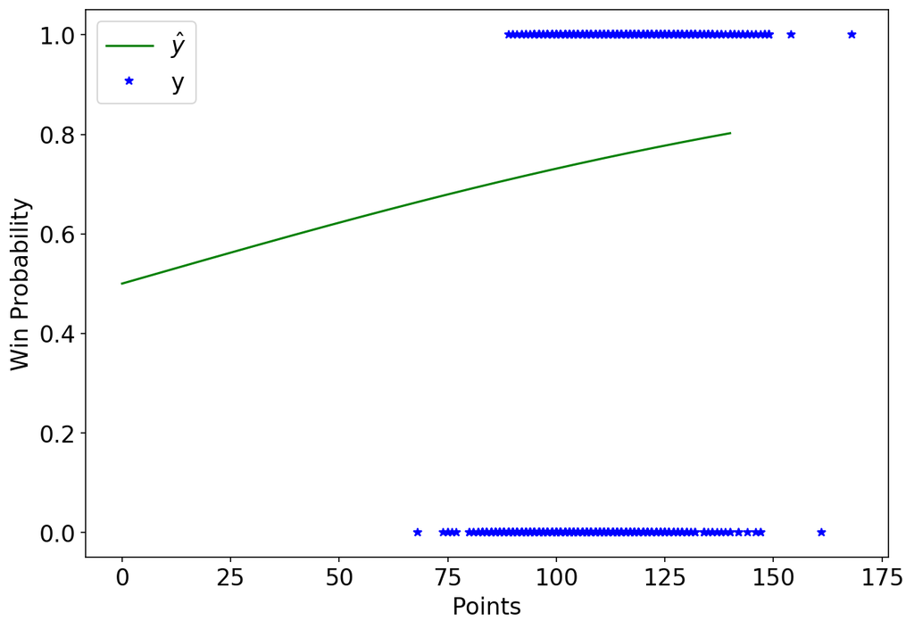

```python
pts = np.linspace(0, 140, 140)

plt.plot(pts, predicted_probability_of_winning_given_pts(pts, w), color = 'green')
plt.plot(x, y_obs, 'b*')

plt.ylabel("Win Probability")
plt.xlabel("Points")
plt.legend(['$\hat{y}$', 'y']);
```

Note that all the probabilities are greater than 0.5. We should not expect a team scoring nearly 0 points to have probability greater than 0.5 of winning.

### Question 2

```python
points_and_intercept = pd.DataFrame(data = {
    'intercept' : 1,
    'PTS' : nba["PTS"]
})
points_and_intercept
```

|  | intercept | PTS |
| --- | --- | --- |
| 0 | 1 | 108 |
| 1 | 1 | 100 |
| 2 | 1 | 87 |
| 3 | 1 | 105 |
| 4 | 1 | 108 |
| ... | ... | ... |
| 2455 | 1 | 99 |
| 2456 | 1 | 122 |
| 2457 | 1 | 114 |
| 2458 | 1 | 132 |
| 2459 | 1 | 117 |

2460 rows × 2 columns

### Question 2.1

The prediction $\hat{y}$ is $$\hat{y} = \sigma(w_0 x_0 + w_1 x_1)$$ Here the two parameters are slope $w_1$ and intercept $w_0$. The features are $x_1$ corresponding to `PTS` and $x_0$ corresponding to `intercept`.

We want to modify `predicted_probability_of_winning_given_pts` from Question 1.1 to allow for two parameters and two features.

```python
def predicted_probability_of_winning_given_features(X, w):
    t = np.dot(X,w)



    return sigma(t)
```

```python
# TEST

assert np.allclose(predicted_probability_of_winning_given_features(points_and_intercept.iloc[0:3, :], np.array([-10,0.1])), np.array([0.6899744811276126, 0.5, 0.21416501695744153]))

assert np.allclose(predicted_probability_of_winning_given_features(points_and_intercept.iloc[0:3, :], np.array([1,0.01])), np.array([0.8889440332885924, 0.8807970779778823, 0.8664582774667876]))
```

### Question 2.2

Suppose $w_1 = 0.05$ and $w_0 = -5$. We can compute the predicted probability that each team won or lost. In particular, we can generate a chart like in Question 1.2.

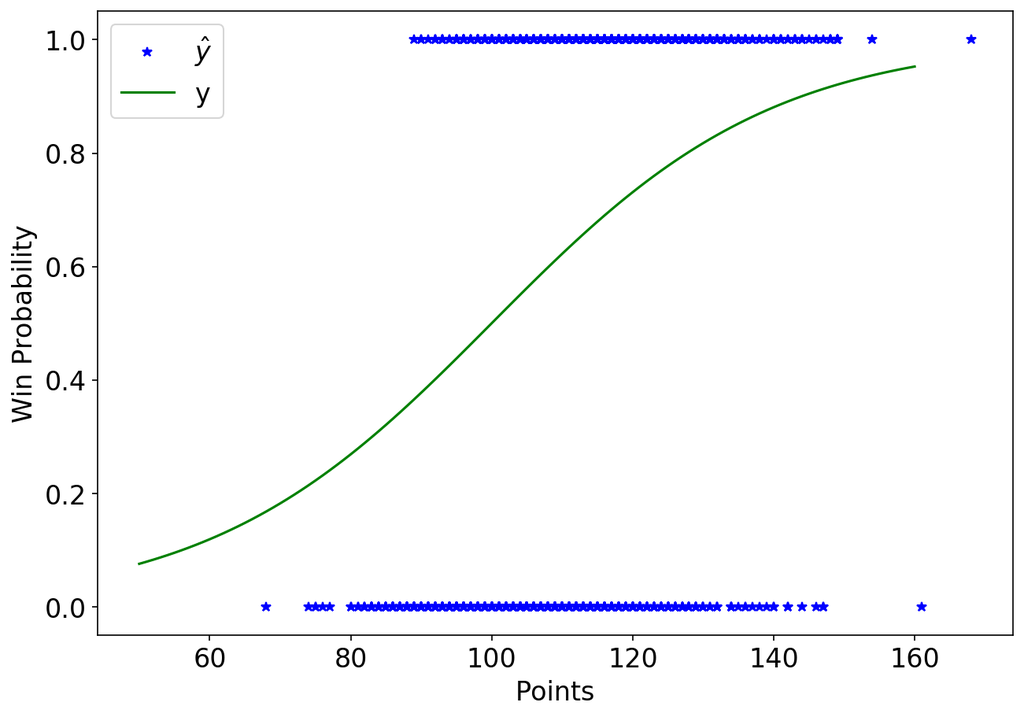

```python
plt.plot(nba["PTS"], nba["WON"], 'b*')

w = [-5, 0.05]
pts = np.linspace(50, 160, 111).reshape(-1, 1)
intercept = np.ones(len(pts)).reshape(-1, 1)

plt.plot(pts, predicted_probability_of_winning_given_features(np.hstack((intercept, pts)), w), 'green')
plt.ylabel("Win Probability")
plt.xlabel("Points")
plt.legend(['$\hat{y}$', 'y']);
```

If we increase the value of $w_0$ then does the do we shift the curve to the left or the right?

```python
q22 = "left"
```

```python
# TEST

assert q22 in ["left", "right"]
```

### Question 2.3

We want to adjust $w_1$ and $w_0$ to get a curve centered at 100 points. We take $w_1 = 0.2$. Determine $w_0$ so $\hat{y}$ equals 0.5 for $x = 100$. Remember that $\sigma(t) = 0.5$ when $t = 0$.

```python
w1 = 0.2
w0 = -20
```

```python
# TEST

x2 = np.array([80, 100, 120])
x1 = np.ones(3)
x = np.vstack((x1, x2)).T

prob80, prob100, prob120 = predicted_probability_of_winning_given_features(x, np.array([w0, w1]))

assert prob80 < 0.05
assert np.allclose(prob100, 0.5)
assert prob120 > 0.95
```

Now we can plot the curve.

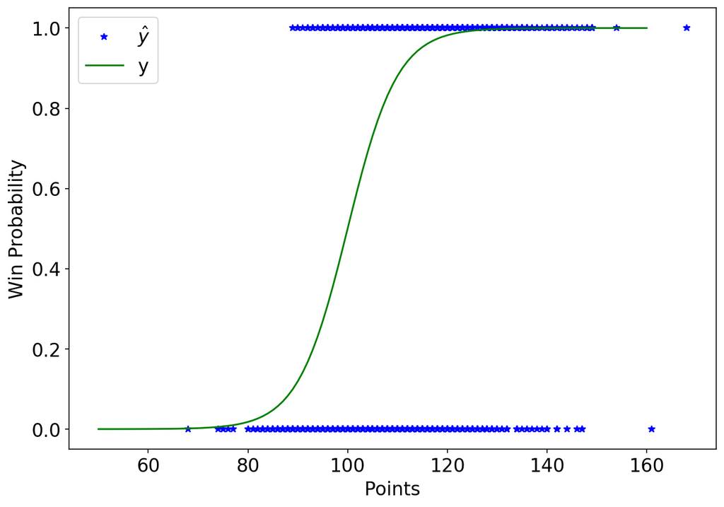

```python
plt.plot(nba["PTS"], nba["WON"], 'b*')
w = [w0, w1]

pts = np.linspace(50, 160, 111).reshape(-1, 1)
intercept = np.ones(len(pts)).reshape(-1, 1)
point_range_and_bias = np.hstack((intercept,pts))

plt.plot(pts, predicted_probability_of_winning_given_features(point_range_and_bias, w), 'green')
plt.ylabel("Win Probability")
plt.xlabel("Points")
plt.legend(['$\hat{y}$', 'y']);
```

### Question 3

We need to determine $\hat{w_0}$ and $\hat{w_1}$ that fit the data through minimization of a loss fuction.

### Question 3.1

Write a function `mse` that comptues mean square error for two arrays consisting of observed values and predicted values.

```python
def mse(observed, predicted):
    return np.mean(np.square(observed - predicted))
```

Now we write a function `mse_for_model_on_NBA_data(beta)` that takes parameters and returns the mean square error between observations and predictions.

```python
def mse_for_model_on_NBA_data(w):
    y_hat = predicted_probability_of_winning_given_features(points_and_intercept, w)
    y_obs = nba["WON"]
    return mse(y_obs, y_hat)
```

```python
# TEST

assert np.isclose(mse_for_model_on_NBA_data(np.array([-20, 0.02])), 0.49999997804309343)
```

### Question 3.2

The cell below plots your mean square error function. Note that the surface has flat region. Here gradient descent will not make progress.

```python
num_points = 50 # increase for better resolution, but it will run more slowly.

uvalues = np.linspace(-20, 20, num_points)
vvalues = np.linspace(-0.3, 0.3, num_points)
(u,v) = np.meshgrid(uvalues, vvalues)
thetas = np.vstack((u.flatten(),v.flatten()))

MSE = np.array([mse_for_model_on_NBA_data(t) for t in thetas.T])

loss_surface = go.Surface(x=u, y=v, z=np.reshape(MSE, u.shape))

fig = go.Figure(data=[loss_surface])
fig.update_layout(scene = dict(
    xaxis_title = "intercept",
    yaxis_title = "slope",
    zaxis_title = "MSE"))
fig.show()
```

[interactive chart not shown]

### Question 3.3

We want to find $\hat{w_0}$ and $\hat{w_1}$ that minimize the mean square error. We will use the `minimize` function from the scipy package.

```python
w = minimize(mse_for_model_on_NBA_data, x0 = [0, 0])['x']
```

```python
# TEST
mse_for_model_on_NBA_data(w) < 0.2
```

```
True
```

Note that `minimize` uses a gradient descent approach. If we take the initial guess to be `[0,-0.2]` then does the gradient descent converge to a minimum? Is `[0,-0.2]` in a flat region of the chart from Question 3.2?

```python
q33 = True
```

```python
# TEST

assert q33 in [True, False]
```

### Question 3.4

How can we use the model for classificaion. We can convert a probability into a category by comparing to a threshold. For example, if $$\hat{y} \geq 0.5$$, then we would classify the team as the winner. If $$\hat{y} < 0.5$$ then we would classify the team as loser. Here the threshold is 0.5.

```python
y_hat = predicted_probability_of_winning_given_features(points_and_intercept, w)
games_and_predictions = nba.copy()
games_and_predictions["predicted_to_win"] = np.round(y_hat)
games_and_predictions[["TEAM_NAME", "GAME_DATE", "WON", "predicted_to_win"]].tail(5)
```

|  | TEAM_NAME | GAME_DATE | WON | predicted_to_win |
| --- | --- | --- | --- | --- |
| 2455 | Denver Nuggets | 2019-04-10 | 1 | 0.0 |
| 2456 | Orlando Magic | 2019-04-10 | 1 | 1.0 |
| 2457 | Charlotte Hornets | 2019-04-10 | 0 | 1.0 |
| 2458 | Memphis Grizzlies | 2019-04-10 | 1 | 1.0 |
| 2459 | Golden State Warriors | 2019-04-10 | 0 | 1.0 |

Here `w` contains the parameters from Question 3.3.

To evaluate the quality of your model, compute the fraction of the rows of `games_and_predictions` for which your model was able to correctly predict the outcome of the game based on only the points scored by one team.

```python
correct = games_and_predictions[games_and_predictions.WON == games_and_predictions.predicted_to_win]
correct = len(correct)
total = len(games_and_predictions)
percentage_correct = correct / total
```

```python
# TEST

assert np.isclose(percentage_correct, 0.7109756097560975)
```

### Question 4

We have an alternative loss function to the square loss called the logistic loss.

```python
def logisitic_loss(y_obs, y_hat):
    eps = 0.00001
    return -np.mean(y_obs * np.log(y_hat + eps) + (1 - y_obs) * np.log(1 - y_hat + eps))
```

Update your function from Question 3.1 to use logistic loss instead of square loss.

```python
def log_loss_for_model_on_NBA_data(w):
    y_hat = predicted_probability_of_winning_given_features(points_and_intercept, w)
    y_obs = nba["WON"]

    return logisitic_loss(y_obs, y_hat)
```

```python
# TEST

assert np.isclose(log_loss_for_model_on_NBA_data(np.array([2, 0.01])), 1.57044965683)
```

### Plotting Cross-Entropy Loss

The cell below plots your cross-entropy loss function. Note that the surface has no big flat regions, which makes it easy to optimize.

Note: Feel free to ignore the divide by zero warning.

```python
num_points = 50 # increase for better resolution, but it will run more slowly.

uvalues = np.linspace(-20, 20, num_points)
vvalues = np.linspace(-0.3, 0.3, num_points)
(u,v) = np.meshgrid(uvalues, vvalues)
thetas = np.vstack((u.flatten(),v.flatten()))

log_loss = np.array([log_loss_for_model_on_NBA_data(t) for t in thetas.T])

loss_surface = go.Surface(x=u, y=v, z=np.reshape(log_loss, u.shape))

fig = go.Figure(data=[loss_surface])
fig.update_layout(scene = dict(
    xaxis_title = "intercept",
    yaxis_title = "slope",
    zaxis_title = "Logistic Loss"))
fig.show()
```

[interactive chart not shown]

In this lab we only fit a logistic regression model one one feature (the number of points) and an intercept term. However, we can easily train a higher dimensional logistic regression model by using more features that provide useful information. For example, we can add the column `FGM` to our model in addition to `PTS`. Note that this is similar to adding features in linear regression.